# SEACAR Coral Analysis: All Indicators

Last compiled on 05 November, 2026

# Important Notes

The purpose of this report is to outline and present the results of Coral Reef analysis based on the data currently available in SEACAR.

All scripts and outputs can be found on the SEACAR GitHub repository:

https://github.com/FloridaSEACAR/SEACAR_Trend_Analyses

This markdown file is designed to be compiled by Coral_Plot_Render.R (https://github.com/FloridaSEACAR/SEACAR_Trend_Analyses/blob/main/Coral/Coral_Plot_Render.R).

See the Data analysis process section below for more information.

# Coral Percent Cover

## Biscayne Bay-Cape Florida to Monroe County Line Aquatic Preserve

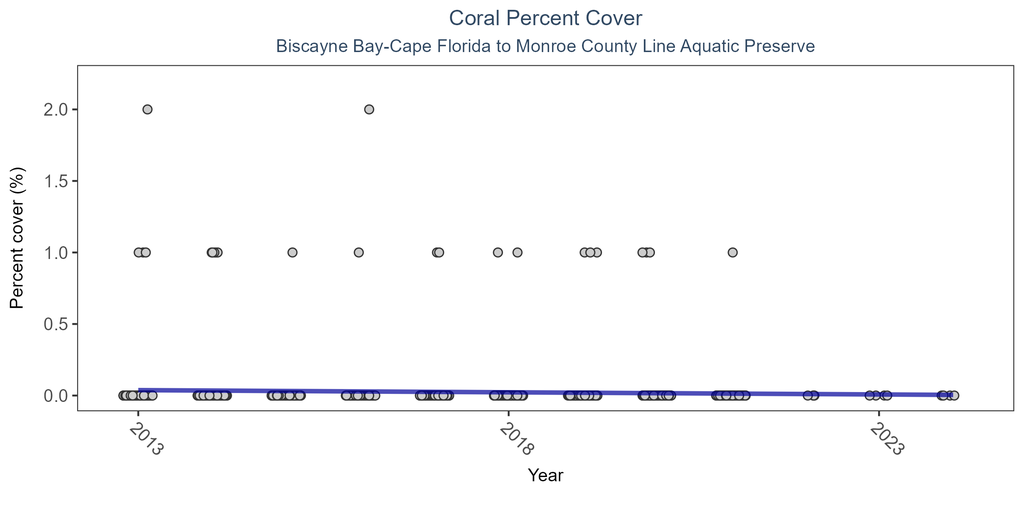

Scatter plot of live coral coverage over time as a percent of reef surface. Species groups include octocorals, milleporans, and scleractinians. If the time series included five or more years of observations, a significant (blue) or non-significant (magenta) trend line is also shown. Data points are jittered horizontally to reduce overlap.

Coral Percent Cover - Biscayne Bay-Cape Florida to Monroe County Line Aquatic Preserve

| Statistical Trend | Period of Record | LME Intercept | LME Slope | p |
| --- | --- | --- | --- | --- |
| No detectable trend | 2013 - 2024 | 6.1 | 0 | 0.14 |

Percent cover showed no detectable trend between 2013 and 2024.

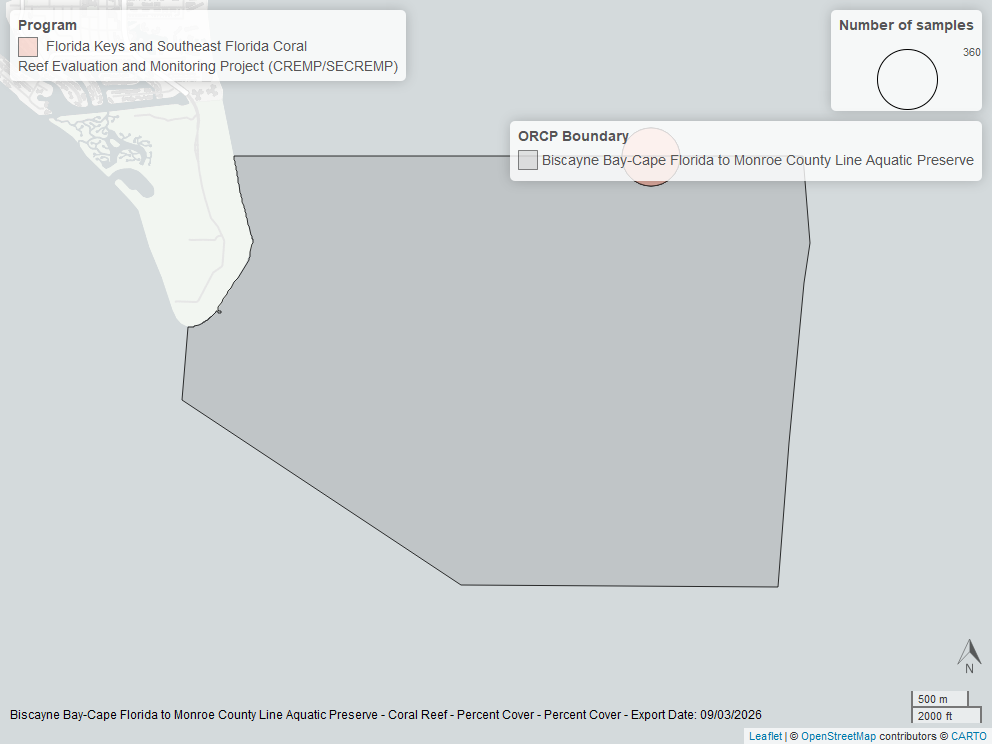

## Coupon Bight Aquatic Preserve

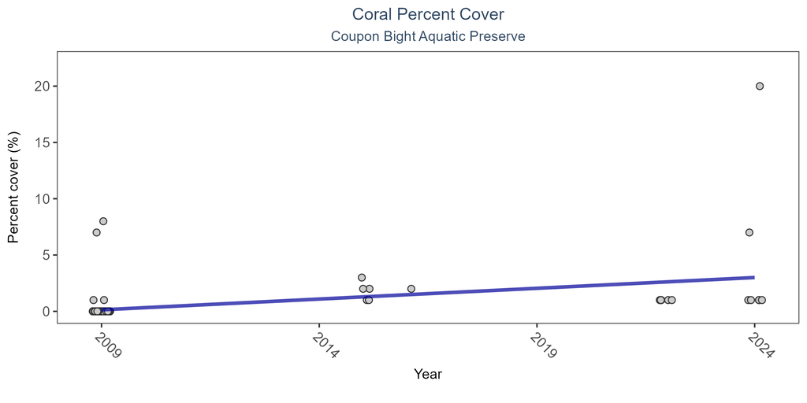

Scatter plot of live coral coverage over time as a percent of reef surface. Species groups include octocorals, milleporans, and scleractinians. If the time series included five or more years of observations, a significant (blue) or non-significant (magenta) trend line is also shown. Data points are jittered horizontally to reduce overlap.

Coral Percent Cover - Coupon Bight Aquatic Preserve

[output not shown]

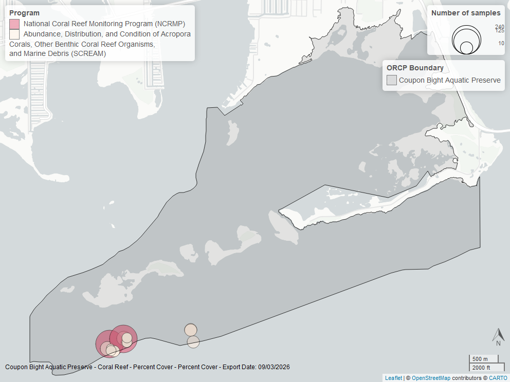

## Florida Keys National Marine Sanctuary

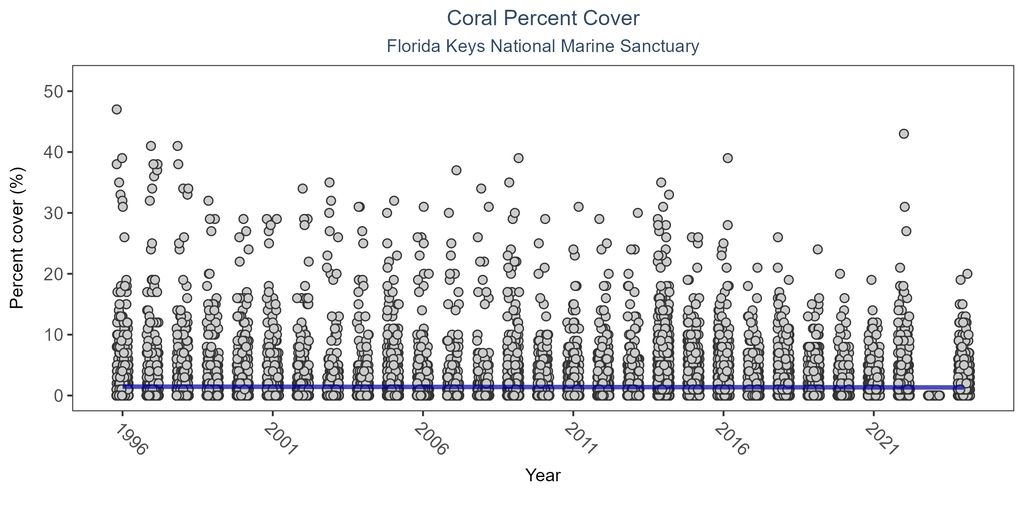

Scatter plot of live coral coverage over time as a percent of reef surface. Species groups include octocorals, milleporans, and scleractinians. If the time series included five or more years of observations, a significant (blue) or non-significant (magenta) trend line is also shown. Data points are jittered horizontally to reduce overlap.

Coral Percent Cover - Florida Keys National Marine Sanctuary

| Statistical Trend | Period of Record | LME Intercept | LME Slope | p |
| --- | --- | --- | --- | --- |
| Decreasing trend | 1996 - 2024 | 11.02 | 0 | 0 |

Annual average percent cover decreased by less than 0.01% between 1996 and 2024.

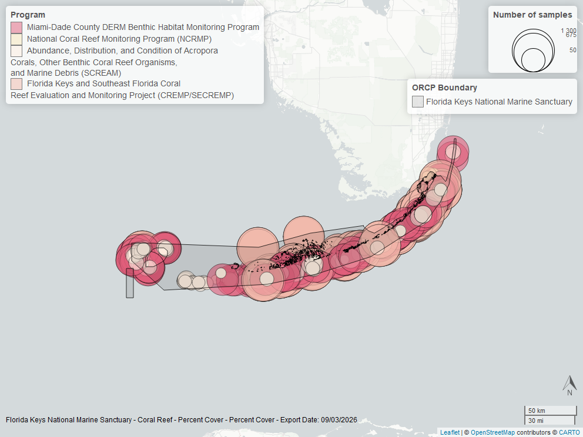

## Kristin Jacobs Coral Aquatic Preserve

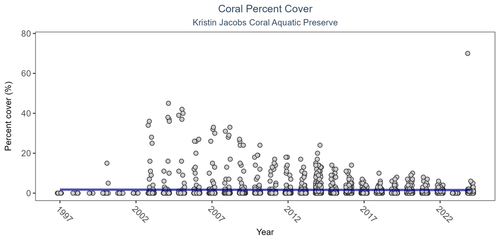

Scatter plot of live coral coverage over time as a percent of reef surface. Species groups include octocorals, milleporans, and scleractinians. If the time series included five or more years of observations, a significant (blue) or non-significant (magenta) trend line is also shown. Data points are jittered horizontally to reduce overlap.

Coral Percent Cover - Kristin Jacobs Coral Aquatic Preserve

| Statistical Trend | Period of Record | LME Intercept | LME Slope | p |
| --- | --- | --- | --- | --- |
| Decreasing trend | 1997 - 2024 | 18.13 | -0.01 | 0 |

Annual average percent cover decreased by 0.01% between 1997 and 2024.

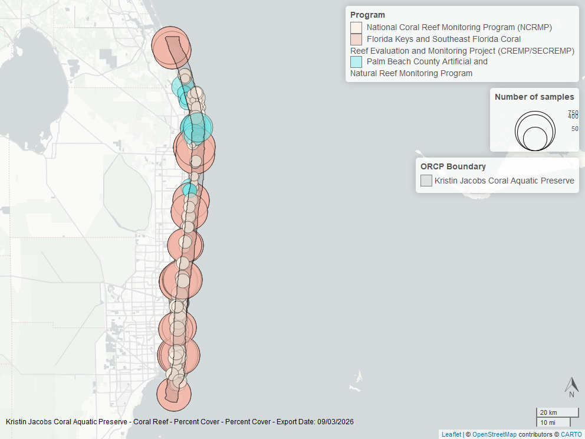

# Coral Grazers and Reef Dependent Species Richness

## Biscayne Bay-Cape Florida to Monroe County Line Aquatic Preserve

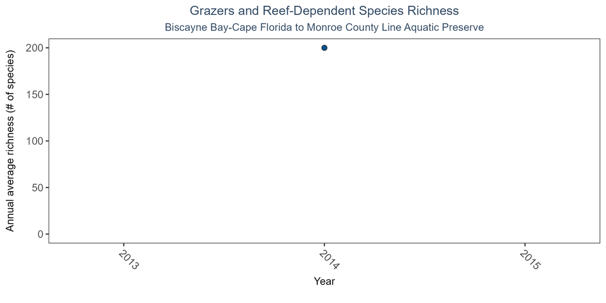

Line graph of annual average species richness of grazers and reef-dependent species over time. If the time series included more than one year of observations, a line connects the data points for visualization.

Coral Grazers and Reef Dependent Species - Biscayne Bay-Cape Florida to Monroe County Line Aquatic Preserve

| N-Years | EarliestYear | LatestYear | N-Data | Min | Max | Median | Mean | StDev | Year-MinRichness | Year-MaxRichness |
| --- | --- | --- | --- | --- | --- | --- | --- | --- | --- | --- |
| 1 | 2014 | 2014 | 2 | 200 | 200 | 200 | 200 | 0 | 2014 | 2014 |

In the year 2014, 200 taxa were observed based on 2 observations.

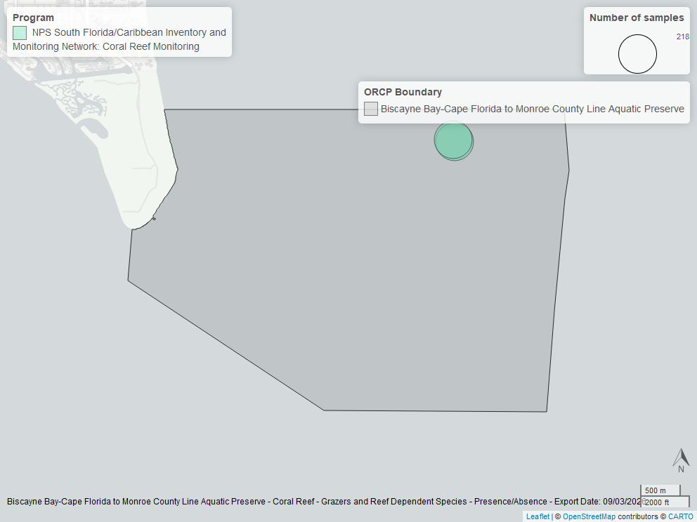

## Coupon Bight Aquatic Preserve

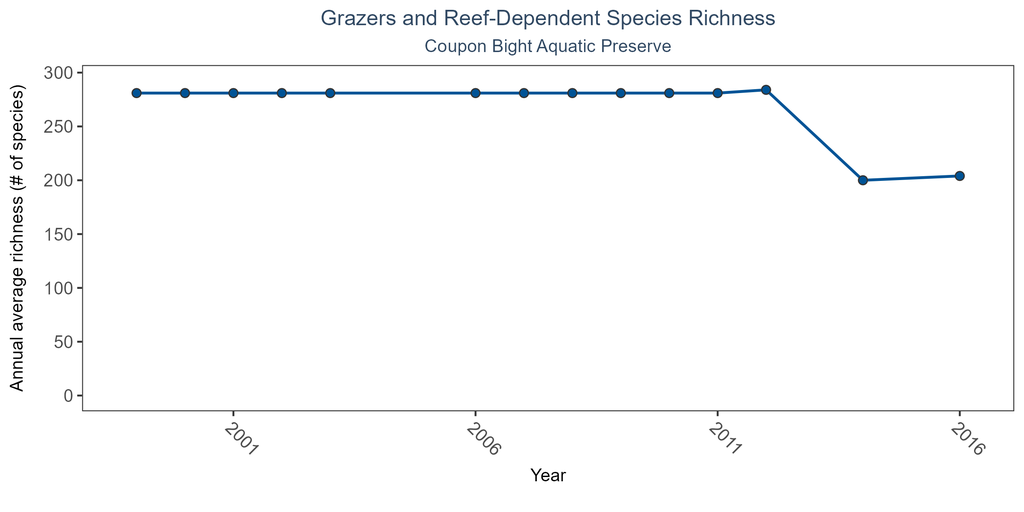

Line graph of annual average species richness of grazers and reef-dependent species over time. If the time series included more than one year of observations, a line connects the data points for visualization.

Coral Grazers and Reef Dependent Species - Coupon Bight Aquatic Preserve

| N-Years | EarliestYear | LatestYear | N-Data | Min | Max | Median | Mean | StDev | Year-MinRichness | Year-MaxRichness |
| --- | --- | --- | --- | --- | --- | --- | --- | --- | --- | --- |
| 14 | 1999 | 2016 | 49 | 200 | 284 | 281 | 266.67 | 30.69 | 2014 | 2012 |

The median annual number of taxa was 281 based on 49 observations collected between 1999 and 2016.

[figure not shown]

## Florida Keys National Marine Sanctuary

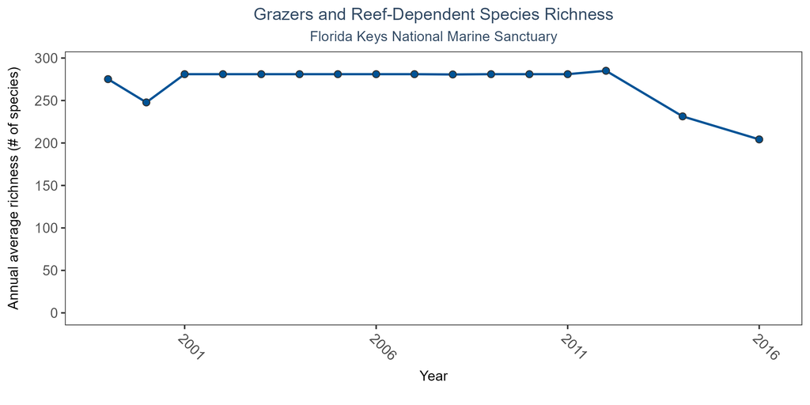

Line graph of annual average species richness of grazers and reef-dependent species over time. If the time series included more than one year of observations, a line connects the data points for visualization.

Coral Grazers and Reef Dependent Species - Florida Keys National Marine Sanctuary

| N-Years | EarliestYear | LatestYear | N-Data | Min | Max | Median | Mean | StDev | Year-MinRichness | Year-MaxRichness |
| --- | --- | --- | --- | --- | --- | --- | --- | --- | --- | --- |
| 16 | 1999 | 2016 | 9136 | 182 | 302 | 281 | 268.7 | 30.22 | 2016 | 2012 |

The median annual number of taxa was 281 based on 9,136 observations collected between 1999 and 2016.

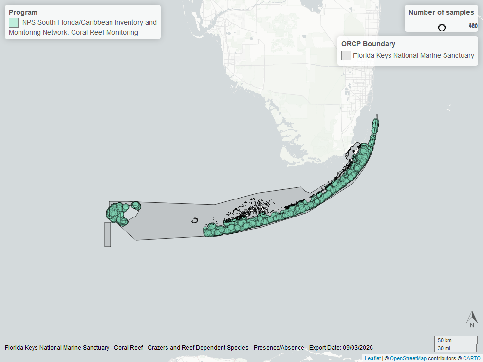

## Kristin Jacobs Coral Aquatic Preserve

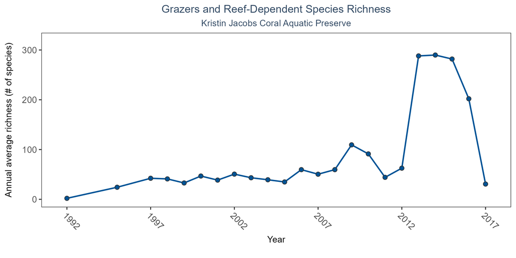

Line graph of annual average species richness of grazers and reef-dependent species over time. If the time series included more than one year of observations, a line connects the data points for visualization.

Coral Grazers and Reef Dependent Species - Kristin Jacobs Coral Aquatic Preserve

| N-Years | EarliestYear | LatestYear | N-Data | Min | Max | Median | Mean | StDev | Year-MinRichness | Year-MaxRichness |
| --- | --- | --- | --- | --- | --- | --- | --- | --- | --- | --- |
| 23 | 1992 | 2017 | 3269 | 1 | 302 | 294 | 218.45 | 108.4 | 1992 | 2014 |

The median annual number of taxa was 294 based on 3,269 observations collected between 1992 and 2017.

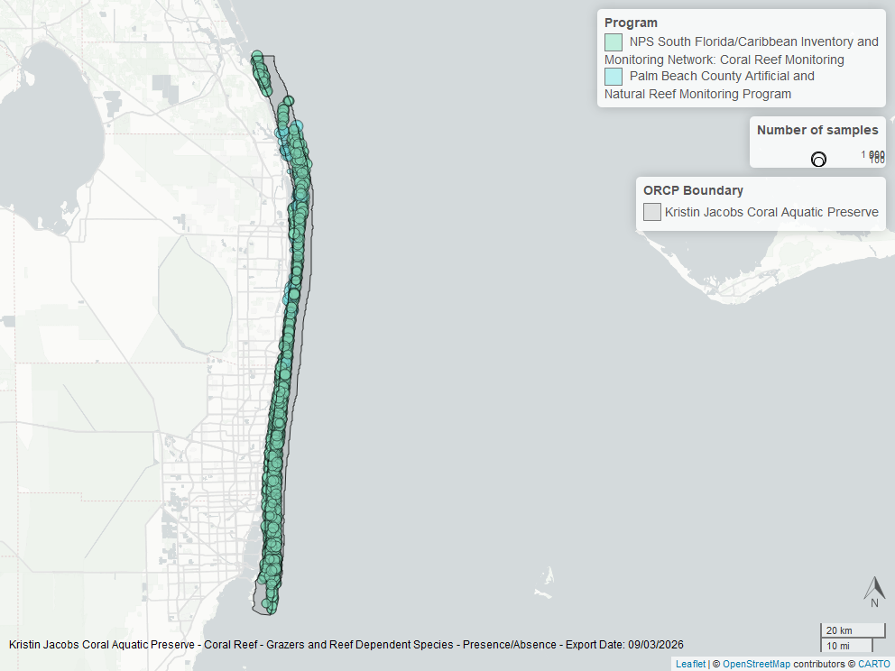

# Coral Community Composition

## Biscayne Bay Aquatic Preserve

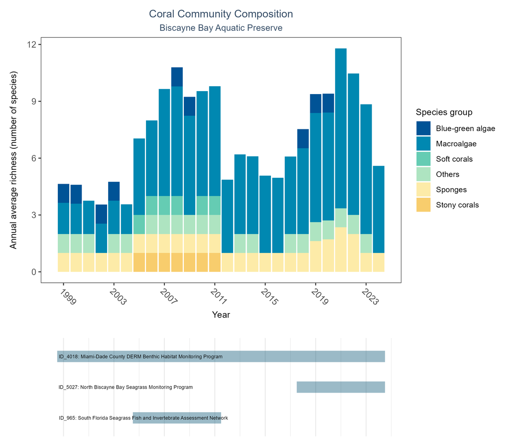

Coral Community Composition - Biscayne Bay Aquatic Preserve

| N-Years | EarliestYear | LatestYear | N-Data | Min | Max | Median | Mean | StDev | Year-MinRichness | Year-MaxRichness |
| --- | --- | --- | --- | --- | --- | --- | --- | --- | --- | --- |
| 26 | 1999 | 2024 | 3130 | 1 | 18 | 3 | 3.99 | 2.87 | 2002 | 2021 |

The median annual number of taxa was 3 based on 3,130 observations collected between 1999 and 2024.

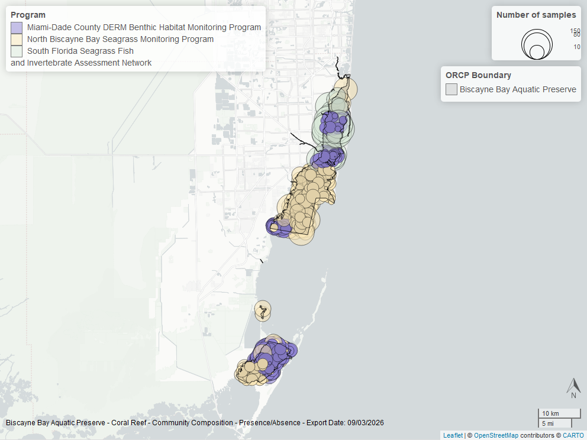

## Florida Keys National Marine Sanctuary

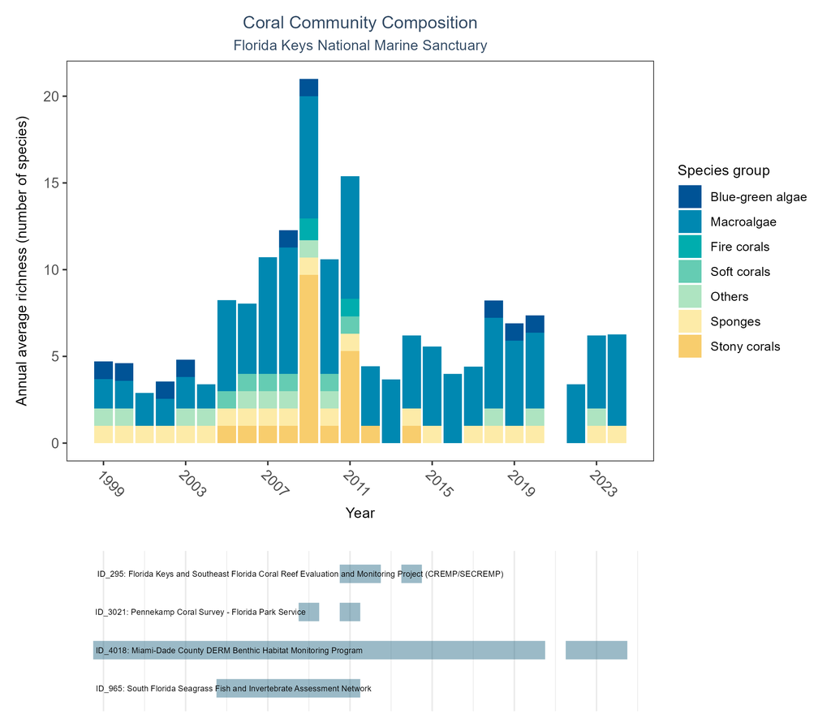

Coral Community Composition - Florida Keys National Marine Sanctuary

| N-Years | EarliestYear | LatestYear | N-Data | Min | Max | Median | Mean | StDev | Year-MinRichness | Year-MaxRichness |
| --- | --- | --- | --- | --- | --- | --- | --- | --- | --- | --- |
| 25 | 1999 | 2024 | 1664 | 1 | 18 | 5 | 5.05 | 3.21 | 2004 | 2009 |

The median annual number of taxa was 5 based on 1,664 observations collected between 1999 and 2024.

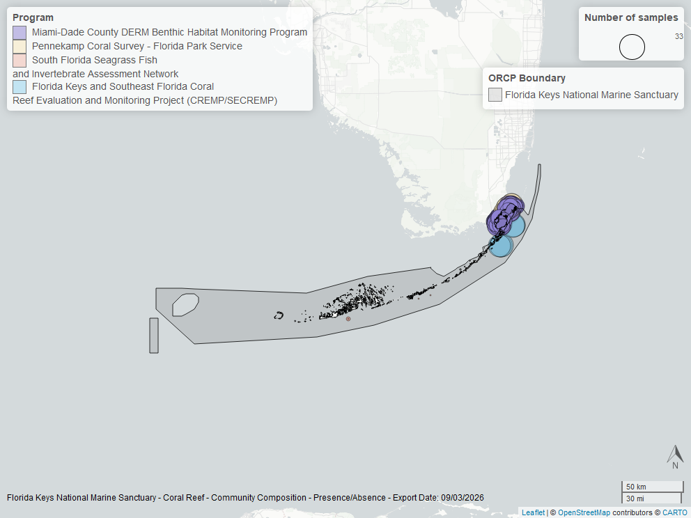

## Kristin Jacobs Coral Aquatic Preserve

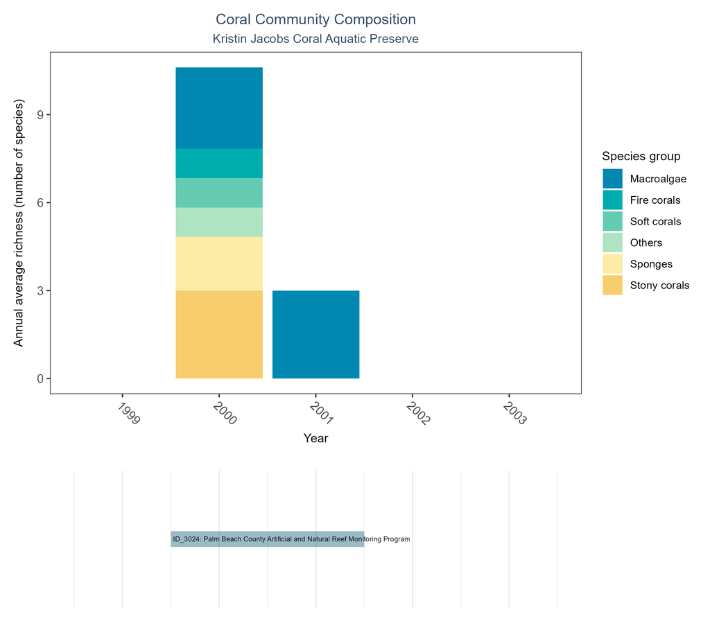

Coral Community Composition - Kristin Jacobs Coral Aquatic Preserve

[output not shown]

The median annual number of taxa was 1.5 based on 24 observations collected between 2000 and 2001.

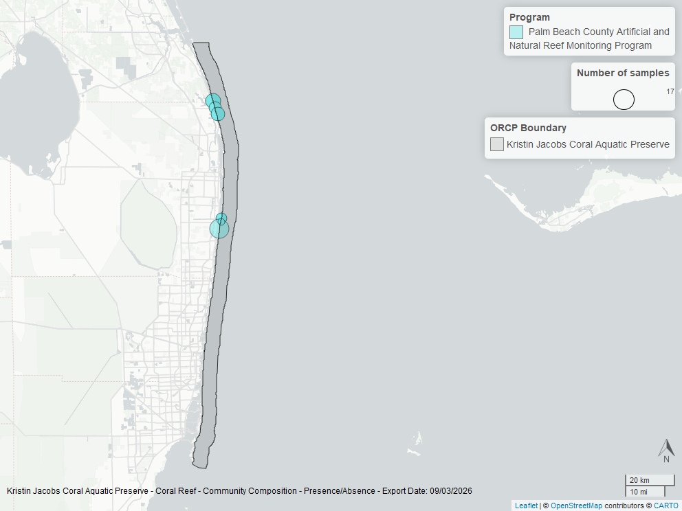

# Data analysis process

The following sections outline the `Coral_Plot_Render.R` script which executes the Coral Reef analyses and generates figures, maps, table descriptions, and .PDF and .HTML reports.

The analytical process for Coral Reef habitat is split into three separate analyses: Percent Cover, Grazers and Reef Dependent Species Richness, and Community Composition. The following sections outline the initial steps that are taken prior to the analyses and apply to all three analyses. The `analysis` variable allows the user to perform the analyses for either ORCP Managed Areas or Coral Regions.

The following programs are excluded from the analysis due to lack of comparability based on SME determinations:

Programs excluded from analysis

| ProgramID | ProgramName |
| --- | --- |
| 136 | Population Status of Elkhorn Coral |
| 981 | Florida Reef Resilience Program |
| 4019 | Post-Hurricane Irma Rapid Assessment |
| 5040 | Coral Disease Monitoring Sentinel Sites |
| 5042 | 2017 Coral Disease Boundary Survey |

For all analyses, summary statistical outputs are created which are grouped by `Year and Month` (MMYY_Stats), `Year` (Yr_Stats), or `Month` (Mo_Stats):

- Amount of data for each grouping (N_Data)
- SpeciesRichness values (Min, Max, Median, Mean, StandardDeviation)
- Program names (Programs) and SEACAR Program ID (ProgramIDs) which contributed data

In addition, all analyses create visualizations in .png format and are archived together into a single .zip file.

```r
library(SEACAR)
library(readr)
library(dplyr)
library(data.table)
library(utils)
library(rstudioapi)
library(lubridate)
library(ggplot2)
library(scales)
library(tidyr)
library(gridExtra)
library(ggpubr)
library(scales)
library(nlme)
library(stringr)
library(knitr)
library(kableExtra)
library(glue)
library(patchwork)
options(scipen=999)

# Choose analysis type (by Managed Area `ma` or by Coral Region `coral_region`)
analysis <- "ma"

# Gets directory of this script and sets it as the working directory
wd <- dirname(getActiveDocumentContext()$path)
setwd(wd)

# Create sample location maps? (for MA Report Generation & Atlas)
create_maps <- TRUE

source("../SEACAR_data_location.R")

#Set output directory
out_dir <- if(analysis=="ma"){
  "output/SpeciesRichness"
} else if(analysis=="coral_region"){
  "output/CoralRegion/SpeciesRichness"
}

#Loads data file with list on managed area names and corresponding area IDs and short names
MA_All <- SEACAR::ManagedAreas

# Load in figure captions (for use in reports)
figureCaptions <- SEACAR::FigureCaptions

#Gets the files with the file names containing the desired parameter
file_in <- list.files(seacar_data_location, pattern="All_CORAL", full=TRUE)

#Gets the specific file used and removes the directory names
file_short <- tail(str_split(file_in, "/")[[1]], 1)

# Read in data file
data <- fread(file_in, sep="|", header=TRUE, stringsAsFactors=FALSE, na.strings="NULL")
# Apply Managed Area transformation - de-concatenate MA names
if(analysis=="ma"){
  data <- setDT(SEACAR::clean_managed_areas(data, "ma", keep_na = FALSE))
}

cat(paste("The data file(s) used:", file_short, sep="\n"))
```

## Coral Grazers and Reef Dependent Species Richness

```r
#Sets abbreviation or label to be used in file names
param_file <- "SpeciesRichness"

## Data Filtering ----
# Only keep data for Presence of grazers and reef-dependent species
data_sr <- data[ParameterName=="Presence/Absence" &
                  SpeciesGroup1 %in% c("Grazers and reef dependent species",
                                       "Reef fish"), ]

# Rename P/A to Species Richness
data_sr$ParameterName <- "Species Richness"
parameter <- "Species Richness"
title_param <- "Species Richness - Grazers and Reef-Dependent Species"

# Sets units for species richness
unit <- "# of species"
data_sr$ParameterUnits <- unit

# Remove rows with missing ManagedAreaName/Coral Region, GenusName, SpeciesName, Months, Years, SpeciesGroup1
data_sr <- data_sr[!is.na(get(analysis_col)) & get(analysis_col)!="NA"]
data_sr <- data_sr[!is.na(GenusName) & !is.na(SpeciesName) & !is.na(Month) &
                     !is.na(Year) & !is.na(SpeciesGroup1)]
# Remove rows where ResultValue is 0 and missing
data_sr <- data_sr[ResultValue!=0 & !is.na(ResultValue)]

# Create Species Richness values for groups of unique combinations of
# ManagedAreaName/CoralRegion, ProgramID, ProgramName, ProgramLocationID, and SampleDate.
data_sr <- data_sr[ResultValue==1] %>%
  group_by(AreaID, !!sym(analysis_col), ProgramID, ProgramName, ProgramLocationID,
           SampleDate) %>%
  summarise(ParameterName=parameter,
            Year=unique(Year), Month=unique(Month),
            SpeciesRichness=length(unique(CommonIdentifier))) %>%
  as.data.table()

# Writes this data that is used by the rest of the script to a text file
fwrite(data_sr, paste0(out_dir,"/Coral_", param_file, "_UsedData.txt"), sep="|")

# Makes sure SampleDate is being stored as a Date object
data_sr$SampleDate <- as.Date(data_sr$SampleDate)

# Creates a variable with the names of all the managed areas that contain
# species observations, in alphabetical order
coral_sr_MA_Include <- data_sr[!is.na(SpeciesRichness), unique(get(analysis_col))] %>% sort()

# Determines the number of managed areas used
n <- length(coral_sr_MA_Include)

## Managed Area Stats ----
# Determine columns to group by
cols_to_group <- c(analysis_col, "Year", "Month")
if(analysis=="ma"){
  cols_to_group <- c("AreaID", cols_to_group)
}
# Create summary statistics for each managed area based on Year and Month
# intervals.
MA_YM_Stats <- data_sr %>%
  group_by(across(all_of(cols_to_group))) %>%
  summarize(ParameterName=parameter,
            N_Data=length(na.omit(SpeciesRichness)),
            Min=min(SpeciesRichness),
            Max=max(SpeciesRichness),
            Median=median(SpeciesRichness),
            Mean=mean(SpeciesRichness),
            StandardDeviation=sd(SpeciesRichness),
            Programs=paste(sort(unique(ProgramName), decreasing=FALSE), collapse=', '),
            ProgramIDs=paste(sort(unique(ProgramID), decreasing=FALSE), collapse=', '),
            .groups = "keep") %>%
  arrange(!!sym(analysis_col), Year, Month) %>%
  as.data.table()
# Writes summary statistics to file
fwrite(MA_YM_Stats, paste0(out_dir,"/Coral_", param_file, "_MA_MMYY_Stats.txt"), sep="|")
# Removes variable storing data to improve computer memory
rm(MA_YM_Stats)

# Determine columns to group by
cols_to_group <- c(analysis_col, "Year")
if(analysis=="ma"){
  cols_to_group <- c("AreaID", cols_to_group)
}

# Create summary statistics for each managed area based on Year intervals
MA_Y_Stats <- data_sr %>%
  group_by(across(all_of(cols_to_group))) %>%
  summarize(ParameterName=parameter,
            N_Data=length(na.omit(SpeciesRichness)),
            Min=min(SpeciesRichness),
            Max=max(SpeciesRichness),
            Median=median(SpeciesRichness),
            Mean=mean(SpeciesRichness),
            StandardDeviation=sd(SpeciesRichness),
            Programs=paste(sort(unique(ProgramName), decreasing=FALSE), collapse=', '),
            ProgramIDs=paste(sort(unique(ProgramID), decreasing=FALSE), collapse=', '),
            .groups = "keep") %>%
  arrange(!!sym(analysis_col), Year) %>%
  as.data.table()
# Writes summary statistics to file
fwrite(MA_Y_Stats, paste0(out_dir,"/Coral_", param_file, "_MA_Yr_Stats.txt"), sep="|")

# Determine columns to group by
cols_to_group <- c(analysis_col, "Month")
if(analysis=="ma"){
  cols_to_group <- c("AreaID", cols_to_group)
}

# Create summary statistics for each managed area based on Month intervals.
MA_M_Stats <- data_sr %>%
  group_by(across(all_of(cols_to_group))) %>%
  summarize(ParameterName=parameter,
            N_Data=length(na.omit(SpeciesRichness)),
            Min=min(SpeciesRichness),
            Max=max(SpeciesRichness),
            Median=median(SpeciesRichness),
            Mean=mean(SpeciesRichness),
            StandardDeviation=sd(SpeciesRichness),
            Programs=paste(sort(unique(ProgramName), decreasing=FALSE), collapse=', '),
            ProgramIDs=paste(sort(unique(ProgramID), decreasing=FALSE), collapse=', '),
            .groups = "keep") %>%
  arrange(!!sym(analysis_col), Month) %>%
  as.data.table()
# Writes summary statistics to file
fwrite(MA_M_Stats, paste0(out_dir,"/Coral_", param_file, "_MA_Mo_Stats.txt"), sep="|")
# Removes variable storing data to improve computer memory
rm(MA_M_Stats)

# Determine columns to group by
cols_to_group <- if(analysis=="ma"){
  c("AreaID", analysis_col)
} else {
  c(analysis_col)
}

# Create summary overall statistics for each managed area.
MA_Ov_Stats <- data_sr %>%
  group_by(across(all_of(cols_to_group))) %>%
  summarize(ParameterName=parameter,
            N_Years=length(unique(na.omit(Year))),
            EarliestYear=min(Year),
            LatestYear=max(Year),
            N_Data=length(na.omit(SpeciesRichness)),
            Min=min(SpeciesRichness),
            Max=max(SpeciesRichness),
            Median=median(SpeciesRichness),
            Mean=mean(SpeciesRichness),
            StandardDeviation=sd(SpeciesRichness),
            Programs=paste(sort(unique(ProgramName), decreasing=FALSE), collapse=', '),
            ProgramIDs=paste(sort(unique(ProgramID), decreasing=FALSE), collapse=', '),
            Year_MinRichness = NA,
            Year_MaxRichness = NA,
            .groups = "keep") %>%
  arrange(!!sym(analysis_col)) %>%
  as.data.table()

# Loops through each ManagedAreaName.
# Determines what year the minimum and maximum species richness occurred
for(m in 1:nrow(MA_Ov_Stats)){
  # Stores ManagedAreaName for this row
  ma <- MA_Ov_Stats[[analysis_col]][m]

  # Skips to next row if there are no data for this combination
  if(MA_Ov_Stats$N_Data[m]==0){
    next
  }
  # Gets the minimum and maximum Mean (yearly averages)
  min <- MA_Y_Stats[get(analysis_col)==ma, min(Mean)]
  max <- MA_Y_Stats[get(analysis_col)==ma, max(Mean)]
  #Determines what years those minimum and maximum values occured
  year_min <- MA_Y_Stats[get(analysis_col)==ma & Mean == min, Year]
  year_max <- MA_Y_Stats[get(analysis_col)==ma & Mean == max, Year]
  # Stores the occurrence years of the minimum and maximum into the overall
  # stats for this row
  MA_Ov_Stats$Year_MinRichness[m] <- year_min
  MA_Ov_Stats$Year_MaxRichness[m] <- year_max
}
# Write overall statistics to file
fwrite(MA_Ov_Stats, paste0(out_dir,"/Coral_", param_file, "_MA_Overall_Stats.txt"), sep="|")
# Removes entries from the overall statistics that do not have data.
# Based on presence or absence of EarliestYear
MA_Ov_Stats <- MA_Ov_Stats[!is.na(MA_Ov_Stats$EarliestYear), ]

## Plot Species Richness ----
# Color palette for SEACAR
color_palette <- SEACAR::seacar_palette1

# Remove previous plots before rendering new plots
if(analysis=="ma"){
  plot_files <- c(
    list.files("output/PercentCover/Figures", full=T),
    list.files("output/SpeciesRichness/Figures", full=T),
    list.files("output/CommunityComposition/Figures", full=T)
  )
} else if(analysis=="coral_region"){
  plot_files <- c(
    list.files("output/CoralRegion/PercentCover/Figures", full=T),
    list.files("output/CoralRegion/SpeciesRichness/Figures", full=T),
    list.files("output/CoralRegion/CommunityComposition/Figures", full=T)
  )
}
file.remove(plot_files)

# Loop that cycles through each managed area with data
if(n==0){
  # Prints a statement if there are no managed areas with appropriate data
  print("There are no monitoring locations that qualify.")
} else {
  for(i in 1:n){
    ma <- coral_sr_MA_Include[i]
    # Get abbreviated name for filename
    ma_abrev <- if(analysis=="ma"){
      MA_All[ManagedAreaName==ma, Abbreviation]
    } else if(analysis=="coral_region"){
      gsub(" ", "", ma)
    }
    # Gets data for target managed area
    plot_data <- MA_Y_Stats[get(analysis_col)==ma, ]
    # Determines most recent year with available data for managed area
    t_max <- MA_Ov_Stats[get(analysis_col)==ma, max(LatestYear)]
    # Determines earliest recent year with available data for managed area
    t_min <- MA_Ov_Stats[get(analysis_col)==ma, min(EarliestYear)]
    # Determines how many years of data are present
    t <- t_max-t_min

    # Creates break intervals for plots based on number of years of data
    if(t>=30){
      # Set breaks to every 10 years if more than 30 years of data
      brk <- -10
    }else if(t<30 & t>=10){
      # Set breaks to every 5 years if between 30 and 10 years of data
      brk <- -5
    }else if(t<10 & t>=4){
      # Set breaks to every 2 years if between 10 and 4 years of data
      brk <- -2
    }else if(t<4 & t>=2){
      # Set breaks to every year if between 4 and 2 years of data
      brk <- -1
    }else if(t<2){
      # Set breaks to every year if less than 2 years of data
      brk <- -1
      # Sets t_max to be 1 year greater and t_min to be 1 year lower
      # Forces graph to have at least 3 tick marks
      t_max <- t_max+1
      t_min <- t_min-1
    }
    # Determine range of data values for the managed area
    y_range <- max(plot_data$Mean) - min(plot_data$Mean)

    # Determines lower bound of y-axis based on data range.
    y_min <- 0

    # Sets upper bound of y-axis to be 10% of the data range above the
    # maximum value.
    y_max <- max(plot_data$Mean)+(0.1*y_range)

    # Location subtitle for plot display
    loc_subtitle <- if(analysis=="ma") ma else {
      paste(ma, "Coral Region")
    }

    # Creates plot object using plot_data.
    # Data is plotted as symbols with connected lines.
    p1 <- ggplot(data=plot_data) +
      geom_line(aes(x=Year, y=Mean), color=color_palette[1],
                linewidth=0.75, alpha=1) +
      geom_point(aes(x=Year, y=Mean), fill=color_palette[1],
                 shape=21, size=2, color="#333333", alpha=1) +
      labs(title="Grazers and Reef-Dependent Species Richness",
           subtitle=loc_subtitle,
           x="Year", y="Annual average richness (# of species)") +
      scale_x_continuous(limits=c(t_min-0.25, t_max+0.25),
                         breaks=seq(t_max, t_min, brk)) +
      scale_y_continuous(limits=c(y_min, y_max),
                         breaks=pretty_breaks(n=5)) +
      SEACAR::SEACAR_plot_theme()
    # Sets file name of plot created
    outname <- paste0("Coral_", param_file, "_", ma_abrev, ".png")
    # Saves plot as a png image
    ggsave(filename = paste0(out_dir, "/Figures/", outname),
           plot = p1,
           width = 8,
           height = 4,
           units = "in")
  }
}

#Gets list of all image files in output/Figures and creates zip directory
fig_list <- list.files(paste0(out_dir, "/Figures"), pattern=".png", full=FALSE)
setwd(paste0(out_dir, "/Figures"))
folder_name <- if(analysis=="ma"){
  "CoralSpeciesRichnessFigures"
} else if(analysis=="coral_region"){
  "CoralSpeciesRichnessFigures_CoralRegion"
}
zip(folder_name, files=fig_list)
setwd(wd)
```

## Coral Percent Cover

The analyses for percent cover involve the use of percent cover data, filtered for the following SpeciesGroup1 values: `Octocorals`, `Milleporans`, and `Scleractinians`. Linear mixed-effects (LME) models (from R package `nlme`) are performed in order to analyze the annual changes in the coverage of coral reef species over time. The models include sample location as a random effect to account for the fact that the locations sampled within a managed area in any given year represent only a handful of the many possible sampling locations. The models are only run for managed areas that had time series with at least five years of data.

```r
# Set seed
seed <- 42
#Set output directory
out_dir <- if(analysis=="ma"){
  "output/PercentCover"
} else if(analysis=="coral_region"){
  "output/CoralRegion/PercentCover"
}

#Sets abbreviation or label to be used in file names
param_file <- "PC"

# Filtering ----
# Only keep data for Percent Cover
# Formerly "Percent Cover - Species Composition"
data_pc <- data[ParameterName=="Percent Cover", ]

# Sets units for percent cover
unit <- "%"
data_pc$ParameterUnits <- unit

# Remove any rows that are not corals, missing GenusName, SpeciesName, Months, Years,
# SpeciesGroup1, ResultValue, SampleDate, ManagedAreaName / Coral Region
data_pc <- data_pc[SpeciesGroup1 %in% c("Octocorals","Milleporans","Scleractinians") &
                     !is.na(GenusName) & !is.na(SpeciesName) & !is.na(Month) &
                     !is.na(Year) & !is.na(SpeciesGroup1) & !is.na(ResultValue) &
                     !is.na(SampleDate) & !is.na(get(analysis_col))]

# # Writes this data that is used by the rest of the script to a text file (too large to share)
# fwrite(data_pc, paste0(out_dir,"/Coral_", param_file, "_UsedData.txt"), sep="|")

## Managed Area Stats ----
# Determine columns to group by
cols_to_group <- c(analysis_col, "Year", "Month")
if(analysis=="ma"){
  cols_to_group <- c("AreaID", cols_to_group)
}

# Create summary statistics for each managed area based on Year and Month
# intervals.
MA_YM_Stats <- data_pc %>%
  group_by(across(all_of(cols_to_group))) %>%
  summarize(ParameterName=parameter,
            N_Data=length(na.omit(ResultValue)),
            Min=min(ResultValue),
            Max=max(ResultValue),
            Median=median(ResultValue),
            Mean=mean(ResultValue),
            StandardDeviation=sd(ResultValue),
            Programs=paste(sort(unique(ProgramName), decreasing=FALSE), collapse=', '),
            ProgramIDs=paste(sort(unique(ProgramID), decreasing=FALSE), collapse=', '),
            .groups = "keep") %>%
  arrange(!!sym(analysis_col), Year, Month) %>%
  as.data.table()
# Writes summary statistics to file
fwrite(MA_YM_Stats, paste0(out_dir,"/Coral_", param_file, "_MA_MMYY_Stats.txt"), sep="|")
# Removes variable storing data to improve computer memory
rm(MA_YM_Stats)

# Determine columns to group by
cols_to_group <- c(analysis_col, "Year")
if(analysis=="ma"){
  cols_to_group <- c("AreaID", cols_to_group)
}

# Create summary statistics for each managed area based on Year intervals
MA_Y_Stats <- data_pc %>%
  group_by(across(all_of(cols_to_group))) %>%
  summarize(ParameterName=parameter,
            N_Data=length(na.omit(ResultValue)),
            Min=min(ResultValue),
            Max=max(ResultValue),
            Median=median(ResultValue),
            Mean=mean(ResultValue),
            StandardDeviation=sd(ResultValue),
            Programs=paste(sort(unique(ProgramName), decreasing=FALSE), collapse=', '),
            ProgramIDs=paste(sort(unique(ProgramID), decreasing=FALSE), collapse=', '),
            .groups = "keep") %>%
  arrange(!!sym(analysis_col), Year) %>%
  as.data.table()
# Writes summary statistics to file
fwrite(MA_Y_Stats, paste0(out_dir,"/Coral_", param_file, "_MA_Yr_Stats.txt"), sep="|")

# Determine columns to group by
cols_to_group <- c(analysis_col, "Month")
if(analysis=="ma"){
  cols_to_group <- c("AreaID", cols_to_group)
}

# Create summary statistics for each managed area based on Month intervals.
MA_M_Stats <- data_pc %>%
  group_by(across(all_of(cols_to_group))) %>%
  summarize(ParameterName=parameter,
            N_Data=length(na.omit(ResultValue)),
            Min=min(ResultValue),
            Max=max(ResultValue),
            Median=median(ResultValue),
            Mean=mean(ResultValue),
            StandardDeviation=sd(ResultValue),
            Programs=paste(sort(unique(ProgramName), decreasing=FALSE), collapse=', '),
            ProgramIDs=paste(sort(unique(ProgramID), decreasing=FALSE), collapse=', '),
            .groups = "keep") %>%
  arrange(!!sym(analysis_col), Month) %>%
  as.data.table()
# Writes summary statistics to file
fwrite(MA_M_Stats, paste0(out_dir,"/Coral_", param_file, "_MA_Mo_Stats.txt"), sep="|")
# Removes variable storing data to improve computer memory
rm(MA_M_Stats)

# Determine columns to group by
cols_to_group <- if(analysis=="ma"){
  c("AreaID", analysis_col)
} else {
  c(analysis_col)
}

# Create summary overall statistics for each managed area.
MA_Ov_Stats <- data_pc %>%
  group_by(across(all_of(cols_to_group))) %>%
  summarize(ParameterName=parameter,
            N_Years=length(unique(na.omit(Year))),
            SufficientData=ifelse(N_Years>=5, TRUE, FALSE),
            EarliestYear=min(Year),
            LatestYear=max(Year),
            N_Data=length(na.omit(ResultValue)),
            Min=min(ResultValue),
            Max=max(ResultValue),
            Median=median(ResultValue),
            Mean=mean(ResultValue),
            StandardDeviation=sd(ResultValue),
            Programs=paste(sort(unique(ProgramName), decreasing=FALSE), collapse=', '),
            ProgramIDs=paste(sort(unique(ProgramID), decreasing=FALSE), collapse=', '),
            .groups = "keep") %>%
  arrange(!!sym(analysis_col)) %>%
  as.data.table()

# Write overall statistics to file
fwrite(MA_Ov_Stats, paste0(out_dir,"/Coral_", param_file, "_MA_Overall_Stats.txt"), sep="|")
# Creates a variable with the names of all the managed areas that contain
# species observations
coral_pc_MA_Include <- MA_Ov_Stats[!is.na(Mean) & SufficientData==TRUE,
                                   sort(unique(get(analysis_col)))]
coral_pc_MA_All <- MA_Ov_Stats[!is.na(Mean), sort(unique(get(analysis_col)))]

# Determines the number of managed areas used
n <- length(coral_pc_MA_Include)

# LME ----
# Creates blank data frame with number of rows defined by how many managed areas
# are going to be analyzed
# Sets column names for blank data frame
if(analysis=="ma"){
  lme_stats <- data.frame(matrix(ncol = 5, nrow = n))
  colnames(lme_stats) <- c("AreaID", analysis_col, "LME_Intercept", "LME_Slope", "LME_p")
} else {
  lme_stats <- data.frame(matrix(ncol = 4, nrow = n))
  colnames(lme_stats) <- c(analysis_col, "LME_Intercept", "LME_Slope", "LME_p")
}
```

```r
# Begins to loop through each managed area for analysis (which have enough data)
for(i in 1:n){
  ma <- coral_pc_MA_Include[i]
  # Gets data for current managegd area
  lme_data <- data_pc[get(analysis_col)==ma,]
  # params
  pars <- lmeControl(
    maxIter = 200,
    msMaxIter = 500,
    msMaxEval = 1000,
    tolerance = 1e-6,
    msTol = 1e-7
  )
  # Perform LME for relation between ResultValue and Year for current managed area
  fit <- try(
    nlme::lme(
      ResultValue ~ Year,
      random = ~1 | LocationID,
      na.action = na.omit,
      data = lme_data,
      control = pars
    ),
    silent = TRUE
  )

  if(inherits(fit, "try-error")) {
    message("LME failed for: ", ma)
    if(analysis=="ma"){
      lme_stats$AreaID[i] <- unique(lme_data$AreaID)
    }
    lme_stats[[analysis_col]][i] <- ma
    lme_stats$LME_Intercept[i] <- NA
    lme_stats$LME_Slope[i] <- NA
    lme_stats$LME_p[i] <- NA
    next
  }

  # Store information and model fits in appropriate row of data frame
  if(analysis=="ma"){
    lme_stats$AreaID[i] <- unique(lme_data$AreaID)
  }
  lme_stats[[analysis_col]][i] <- ma
  lme_stats$LME_Intercept[i] <- fit$coefficients$fixed[1]
  lme_stats$LME_Slope[i] <- fit$coefficients$fixed[2]
  lme_stats$LME_p[i] <- anova(fit)$p[2]

  # Clears temporary variables for memory
  rm(lme_data)
  rm(fit)
}

# Merges LME stats with overall stats to complete stats for each managed area
if(analysis=="ma"){
  lme_stats <- merge.data.frame(MA_Ov_Stats[,-c("Programs", "ProgramIDs")],
                                lme_stats, by=c("AreaID", analysis_col), all=TRUE)
} else {
  lme_stats <- merge.data.frame(MA_Ov_Stats[,-c("Programs", "ProgramIDs")],
                                lme_stats, by=c(analysis_col), all=TRUE)
}

## Add in TrendText and TrendIcon columns
lme_stats <- lme_stats %>%
  mutate(TrendText = ifelse(LME_p <= 0.05 & LME_Slope > 0, "Increasing trend",
                            ifelse(LME_p <= 0.05 & LME_Slope < 0, "Decreasing trend",
                                   "No detectable trend")),
         TrendIcon = ifelse(LME_p <= 0.05 & LME_Slope > 0, 1,
                            ifelse(LME_p <= 0.05 & LME_Slope < 0, -1, 0))) %>%
  arrange(!!sym(analysis_col)) %>%
  as.data.table()

#filling remaining values in TrendText + TrendIcon column
lme_stats[SufficientData==FALSE, TrendText := "Insufficient data"]
lme_stats[SufficientData==FALSE, TrendIcon := 2]
lme_stats[SufficientData==TRUE & is.na(LME_Slope), TrendText := "Model did not fit the available data"]
lme_stats[SufficientData==TRUE & is.na(LME_Slope), TrendIcon := 3]

# Write lme statistics to file
fwrite(lme_stats, paste0(out_dir,"/Coral_", param_file, "_LME_Stats.txt"), sep="|")

cols_to_group <- if(analysis=="ma"){
  c("AreaID", analysis_col)
} else {
  c(analysis_col)
}
# Gets lower x and y values based on LME fit to use in plot
lme_plot <- lme_stats %>%
  group_by(across(all_of(cols_to_group))) %>%
  summarize(x=EarliestYear,
            y=LME_Slope*x+LME_Intercept, .groups = "keep")
# Gets upper x and y values based on LME fit to use in plot
lme_plot2 <- lme_stats %>%
  group_by(across(all_of(cols_to_group))) %>%
  summarize(x=LatestYear,
            y=LME_Slope*x+LME_Intercept, .groups = "keep")
# Merges LME fit values for plot into one data frame
lme_plot <- bind_rows(lme_plot, lme_plot2)
rm(lme_plot2)
# Puts LME plot data fram in alphabetical order by managed area
lme_plot <- as.data.frame(lme_plot[order(lme_plot[[analysis_col]]), ])
lme_plot <- setDT(lme_plot[!is.na(lme_plot$y),])

# Trendlines_ManagedArea ----
# Create jitter object that sets the height and width
# Sets seed to be reproducible
# plot_jitter <- position_jitter(width = 0.2, height = 0.2, seed=seed)
plot_jitter <- position_jitter(width = 0.2, height = 0, seed=seed)

# Loop that cycles through each managed area with data
if(n==0){
  # Prints a statement if there are no managed areas with appropriate data
  print("There are no locations that qualify.")
} else {
  for(i in 1:length(coral_pc_MA_All)){
    ma <- coral_pc_MA_All[i]
    # Get abbreviated name for filename
    ma_abrev <- if(analysis=="ma"){
      MA_All[ManagedAreaName==ma, Abbreviation]
    } else if(analysis=="coral_region"){
      gsub(" ", "", ma)
    }
    # Gets data for target managed area
    plot_data <- data_pc[get(analysis_col)==ma]
    if(ma %in% coral_pc_MA_Include){
      lme_plot_data <- lme_plot[get(analysis_col)==ma,]
    }

    # Determines most recent year with available data for managed area
    maxyr <- MA_Ov_Stats[get(analysis_col)==ma, max(LatestYear)]
    # Determines earliest recent year with available data for managed area
    minyr <- MA_Ov_Stats[get(analysis_col)==ma, min(EarliestYear)]
    # Determines how many years of data are present
    nyrs <- maxyr-minyr+1

    current_year <- as.integer(format(Sys.Date(), "%Y"))

    # Creates break intervals for plots based on number of years of data
    if(nyrs>=30){
      # Set breaks to every 10 years if more than 30 years of data
      brk <- 10
    }else if(nyrs>=10){
      # Set breaks to every 5 years if between 30 and 10 years of data
      brk <- 5
    }else if(nyrs>=5){
      # Set breaks to every 2 years if between 10 and 5 years of data
      brk <- 2
    } else {
      # Ensure 5 years are included on axis
      total_ticks <- 5
      extra_years <- total_ticks - nyrs
      # Always add 1 year before the first year
      years_before <- min(1, extra_years)
      years_after <- extra_years - years_before
      # Adjust min and max year, without going beyond current year
      minyr <- minyr - years_before
      maxyr <- min(maxyr + years_after, current_year)
      # Re-check if we have enough years (in case maxyr hit current year)
      minyr <- max(minyr, maxyr - (total_ticks - 1))
      brk <- 1
    }
    # Determine range of data values for the managed area
    y_range <- max(plot_data$ResultValue) - min(plot_data$ResultValue)

    # Sets y_min
    if(nrow(lme_plot_data)>0){
      # y_min <- min(min(lme_plot_data$y), min(plot_data$ResultValue))
      y_min <- min(min(lme_plot_data$y), 0)
    } else {
      y_min <- 0
    }
```

```r
    # Sets upper bound of y-axis to be 10% of the data range above the
    # maximum value, unless both min and max are 0.
    if(max(plot_data$ResultValue)==0 & y_min==0){
      y_max <- max(plot_data$ResultValue)+1
    } else {
      y_max <- max(plot_data$ResultValue)+(0.1*y_range)
    }

    # Location subtitle for plot display
    loc_subtitle <- if(analysis=="ma") ma else {
      paste(ma, "Coral Region")
    }

    # Creates plot object using plot_data.
    # Data is plotted as a point pot with jitter to show concentrations
    # that overlap. LME fit is plotted as a line
    p1 <- ggplot(data=plot_data) +
      geom_point(aes(x=Year, y=ResultValue),
                 position=plot_jitter, shape=21, size=2,
                 color="#333333", fill="#cccccc", alpha=1) +
      {if(ma %in% coral_pc_MA_Include){
        geom_line(data=lme_plot_data, aes(x=x, y=y),
                  color="#000099", linewidth=1.2, alpha=0.7)
      }} +
      labs(title="Coral Percent Cover",
           subtitle=loc_subtitle,
           x="Year", y="Percent cover (%)") +
      scale_x_continuous(limits = c(minyr-0.25, maxyr+0.25),
                         breaks = seq(minyr, maxyr, brk)) +
      scale_y_continuous(limits=c(y_min, y_max),
                         breaks=pretty_breaks(n=5)) +
      SEACAR::SEACAR_plot_theme()
    # Sets file name of plot created
    outname <- paste0("Coral_", param_file, "_", ma_abrev, ".png")
    # Saves plot as a png image
    ggsave(filename = paste0(out_dir, "/Figures/", outname),
           plot = p1,
           width = 8,
           height = 4,
           units = "in")
  }
}

#Gets list of all PC image files and creates zip directory
fig_list <- list.files(paste0(out_dir, "/Figures"), pattern=".png", full=FALSE)
setwd(paste0(out_dir, "/Figures"))
folder_name <- if(analysis=="ma"){
  "CoralPCFigures"
} else if(analysis=="coral_region"){
  "CoralPCFigures_CoralRegion"
}
zip(folder_name, files=fig_list)
setwd(wd)
```

## Coral Community Composition

The community composition of coral reefs over time was visualized by plotting the average number of species observed annually within each of nine groups: false corals (*corallimorpharians*), blue-green algae (*cyanobacteria*), *macroalgae*, fire corals (*milleporans*), soft corals (*octocorals*), sponges (*porifera*), stony corals (*scleractinians*), *zoanthids*, and *others*.

```r
# Parameter name
parameter <- "Species Richness (Community Composition)"
# Short hand parametername
param_file <- "CC"
# Output directory location
out_dir <- if(analysis=="ma"){
  "output/CommunityComposition"
} else if(analysis=="coral_region"){
  "output/CoralRegion/CommunityComposition"
}
# Coral species groups included in community composition
comp_species_groups <- c("Corallimorpharians", "Cyanobacteria", "Macroalgae",
                         "Milleporans", "Octocorals", "Porifera", "Scleractinians",
                         "Zoanthids", "Others")
# Their corresponding "common" names
comp_species_groups_common <- data.table(
  "sci_names" = comp_species_groups,
  "common_names" = c("False corals", "Blue-green algae", "Macroalgae",
                     "Fire corals", "Soft corals", "Sponges", "Stony corals",
                     "Zoanthids", "Others")
)
# Programs to exclude (ID_981 only reports scleractinians)
exclude_progs <- c(981)

# Columns to group by
cols_to_group <- c(analysis_col, "ProgramID", "ProgramName", "LocationID",
                   "SampleDate", "SpeciesGroup1")
if(analysis=="ma"){
  cols_to_group <- c("AreaID", cols_to_group)
}

# Filter for the presence of those species groups for each area and LocationID
# This gives us species richness values
data_cc <- data %>%
  filter(
    ParameterName=="Presence/Absence",
    ResultValue==1,
    SpeciesGroup1 %in% comp_species_groups,
    !ProgramID %in% exclude_progs
  ) %>%
  group_by(across(all_of(cols_to_group))) %>%
  reframe(
    ParameterName = parameter,
    Year = unique(Year),
    Month = unique(Month),
    SpeciesRichness = length(unique(CommonIdentifier))
  ) %>% as.data.table()

if(analysis=="coral_region"){
  data_cc[is.na(CoralRegion), `:=` (CoralRegion = "NA")]
}

## Managed Area Stats ----
# Create summary statistics for each managed area based on Year and Month
# intervals.

# Determine columns to group by
cols_to_group <- c(analysis_col, "Year", "Month")
if(analysis=="ma"){
  cols_to_group <- c("AreaID", cols_to_group)
}

MA_YM_Stats <- data_cc %>%
  group_by(across(all_of(cols_to_group))) %>%
  summarize(
    ParameterName=parameter,
    N_Data=length(na.omit(SpeciesRichness)),
    Min=min(SpeciesRichness),
    Max=max(SpeciesRichness),
    Median=median(SpeciesRichness),
    Mean=mean(SpeciesRichness),
    StandardDeviation=sd(SpeciesRichness),
    Programs=paste(sort(unique(ProgramName), decreasing=FALSE), collapse=', '),
    ProgramIDs=paste(sort(unique(ProgramID), decreasing=FALSE), collapse=', '),
    IncludedSpeciesGroups = paste(sort(unique(SpeciesGroup1), decreasing=FALSE),
                                  collapse=', '),
    .groups = "keep"
  ) %>%
  arrange(!!sym(analysis_col), Year, Month) %>%
  as.data.table()
# Writes summary statistics to file
fwrite(MA_YM_Stats, paste0(out_dir,"/Coral_", param_file, "_MA_MMYY_Stats.txt"), sep="|")
# Removes variable storing data to improve computer memory
rm(MA_YM_Stats)

# Determine columns to group by
cols_to_group <- c(analysis_col, "Year")
if(analysis=="ma"){
  cols_to_group <- c("AreaID", cols_to_group)
}

# Create summary statistics for each managed area based on Year intervals
MA_Y_Stats <- data_cc %>%
  group_by(across(all_of(cols_to_group))) %>%
  summarize(
    ParameterName=parameter,
    N_Data=length(na.omit(SpeciesRichness)),
    Min=min(SpeciesRichness),
    Max=max(SpeciesRichness),
    Median=median(SpeciesRichness),
    Mean=mean(SpeciesRichness),
    StandardDeviation=sd(SpeciesRichness),
    Programs=paste(sort(unique(ProgramName), decreasing=FALSE), collapse=', '),
    ProgramIDs=paste(sort(unique(ProgramID), decreasing=FALSE), collapse=', '),
    IncludedSpeciesGroups = paste(sort(unique(SpeciesGroup1), decreasing=FALSE),
                                  collapse=', '),
    .groups = "keep"
  ) %>%
  arrange(!!sym(analysis_col), Year) %>%
  as.data.table()
# Writes summary statistics to file
fwrite(MA_Y_Stats, paste0(out_dir,"/Coral_", param_file, "_MA_Yr_Stats.txt"), sep="|")

# Determine columns to group by
cols_to_group <- c(analysis_col, "Month")
if(analysis=="ma"){
  cols_to_group <- c("AreaID", cols_to_group)
}

# Create summary statistics for each managed area based on Month intervals.
MA_M_Stats <- data_cc %>%
  group_by(across(all_of(cols_to_group))) %>%
  summarize(
    ParameterName=parameter,
    N_Data=length(na.omit(SpeciesRichness)),
    Min=min(SpeciesRichness),
    Max=max(SpeciesRichness),
    Median=median(SpeciesRichness),
    Mean=mean(SpeciesRichness),
    StandardDeviation=sd(SpeciesRichness),
    Programs=paste(sort(unique(ProgramName), decreasing=FALSE), collapse=', '),
    ProgramIDs=paste(sort(unique(ProgramID), decreasing=FALSE), collapse=', '),
    IncludedSpeciesGroups = paste(sort(unique(SpeciesGroup1), decreasing=FALSE), collapse=', '),
    .groups = "keep"
  ) %>%
  arrange(!!sym(analysis_col), Month) %>%
  as.data.table()
# Writes summary statistics to file
fwrite(MA_M_Stats, paste0(out_dir,"/Coral_", param_file, "_MA_Mo_Stats.txt"), sep="|")
# Removes variable storing data to improve computer memory
rm(MA_M_Stats)

# Determine columns to group by
cols_to_group <- if(analysis=="ma"){
  c("AreaID", analysis_col)
} else {
  c(analysis_col)
}

# Create summary overall statistics for each managed area.
MA_Ov_Stats <- data_cc %>%
  group_by(across(all_of(cols_to_group))) %>%
  summarize(
    ParameterName=parameter,
    N_Years=length(unique(na.omit(Year))),
    EarliestYear=min(Year),
    LatestYear=max(Year),
    N_Data=length(na.omit(SpeciesRichness)),
    Min=min(SpeciesRichness),
    Max=max(SpeciesRichness),
    Median=median(SpeciesRichness),
    Mean=mean(SpeciesRichness),
    StandardDeviation=sd(SpeciesRichness),
    Programs=paste(sort(unique(ProgramName), decreasing=FALSE), collapse=', '),
    ProgramIDs=paste(sort(unique(ProgramID), decreasing=FALSE), collapse=', '),
    IncludedSpeciesGroups = paste(sort(unique(SpeciesGroup1), decreasing=FALSE), collapse=', '),
    Year_MinRichness = NA,
    Year_MaxRichness = NA,
    .groups = "keep"
  ) %>%
  arrange(!!sym(analysis_col)) %>%
  as.data.table()
```

```r
# Loops through each ManagedAreaName / Coral Region.
# Determines what year the minimum and maximum species richness occurred
for(m in 1:nrow(MA_Ov_Stats)){
  # Stores ManagedAreaName for this row
  ma <- MA_Ov_Stats[[analysis_col]][m]

  # Skips to next row if there are no data for this combination
  if(MA_Ov_Stats$N_Data[m]==0){
    next
  }
  # Gets the minimum and maximum Mean (yearly averages)
  min <- MA_Y_Stats[get(analysis_col)==ma, min(Mean)]
  max <- MA_Y_Stats[get(analysis_col)==ma, max(Mean)]
  #Determines what years those minimum and maximum values occured
  year_min <- MA_Y_Stats[get(analysis_col)==ma & Mean == min, Year]
  year_max <- MA_Y_Stats[get(analysis_col)==ma & Mean == max, Year]
  # Stores the occurrence years of the minimum and maximum into the overall
  # stats for this row
  MA_Ov_Stats$Year_MinRichness[m] <- year_min
  MA_Ov_Stats$Year_MaxRichness[m] <- year_max
}
# Write overall statistics to file
fwrite(MA_Ov_Stats, paste0(out_dir,"/Coral_", param_file, "_MA_Overall_Stats.txt"), sep="|")

### Create plots
# Determine columns to group by
cols_to_group <- c(analysis_col, "ParameterName", "Year", "SpeciesGroup1")
if(analysis=="ma"){
  cols_to_group <- c("AreaID", cols_to_group)
}

# Condense species richness values into annual averages, min/max, etc.
comp_plot_data <- data_cc %>%
  filter(!!sym(analysis_col) != "NA") %>%
  group_by(across(all_of(cols_to_group))) %>%
  reframe(
    N_Years = length(unique(na.omit(Year))),
    EarliestYear = min(Year),
    LatestYear = max(Year),
    N_Data = length(na.omit(SpeciesRichness)),
    Min = min(SpeciesRichness),
    Max = max(SpeciesRichness),
    Median = median(SpeciesRichness),
    Mean = mean(SpeciesRichness),
    StandardDeviation = sd(SpeciesRichness),
    Programs = paste(sort(unique(ProgramName), decreasing = FALSE), collapse = ", "),
    ProgramIDs = paste(sort(unique(ProgramID), decreasing = FALSE), collapse = ", ")
  ) %>%
  as.data.table()
# Write overall statistics to file
fwrite(comp_plot_data, paste0(out_dir,"/Coral_", param_file, "_UsedData.txt"), sep="|")

# Color palette for SEACAR
color_palette <- SEACAR::seacar_palette1
# All unique SG1 groups
sg1 <- sort(unique(comp_plot_data$SpeciesGroup1))
# Create palette for all SG2 values so it is consistent across all MAs
sg1_palette <- color_palette[seq(1, length(sg1))]
names(sg1_palette) <- sg1

# # # Include common names?
# sg_common <- c("Cephalopods", "Cartilaginous fishes", "Decapod crustaceans",
#                "Bony fishes", "Other Chordata", "Marine turtles")
# names(sg_common) <- sg1

progs <- data.frame(
  ProgramID = comp_plot_data %>% separate_longer_delim(ProgramIDs, ", ") %>%
    pull(ProgramIDs) %>% unique(),
  ProgramName = comp_plot_data %>% separate_longer_delim(Programs, ", ") %>%
    pull(Programs) %>% unique()
)
pids <- unique(progs$ProgramID)
pids_palette <- viridis::viridis(length(pids))
names(pids_palette) <- pids

for(ma in unique(comp_plot_data[[analysis_col]])){
  ma_abrev <- if(analysis=="ma"){
    MA_All[ManagedAreaName==ma, Abbreviation]
  } else if(analysis=="coral_region"){
    gsub(" ", "", ma)
  }
  # Gets data for target managed area
  plot_data <- comp_plot_data[get(analysis_col)==ma, ]
  # Determines most recent year with available data for managed area
  maxyr <- max(plot_data$LatestYear)
  # Determines earliest recent year with available data for managed area
  minyr <- min(plot_data$EarliestYear)
  # Determines how many years of data are present
  nyrs <- maxyr-minyr+1

  current_year <- as.integer(format(Sys.Date(), "%Y"))

  # Creates break intervals for plots based on number of years of data
  if(nyrs>=30){
    brk <- 10
  } else if(nyrs>=10){
    brk <- 4
  } else if(nyrs>=4){
    brk <- 2
  } else {
    # Ensure 5 years are included on axis
    total_ticks <- 5
    extra_years <- total_ticks - nyrs
    # Always add 1 year before the first year
    years_before <- min(1, extra_years)
    years_after <- extra_years - years_before
    # Adjust min and max year, without going beyond current year
    minyr <- minyr - years_before
    maxyr <- min(maxyr + years_after, current_year)
    # Re-check if we have enough years (in case maxyr hit current year)
    minyr <- max(minyr, maxyr - (total_ticks - 1))
    brk <- 1
  }
  # Determine range of data values for the managed area
  y_range <- max(plot_data$Mean) - min(plot_data$Mean)

  # Determines lower bound of y-axis based on data range. Set based on
  # relation of data range to minimum value. Designed to set lower boundary
  # to be 10% of the data range below the minimum value
  y_min <- if(min(plot_data$Mean)-(0.1*y_range)<0){
    # If 10% of the data range below the minimum value is less than 0,
    # set as 0
    y_min <- 0
  } else {
    # Otherwise set minimum bound as 10% data range below minimum value
    y_min <- min(plot_data$Mean)-(0.1*y_range)
  }

  # Sets upper bound of y-axis to be 10% of the data range above the
  # maximum value.
  y_max <- max(plot_data$Mean)+(0.1*y_range)

  ## Legend labels - grab list of unique SG1 for this MA
  sp_list <- unique(plot_data$SpeciesGroup1)
  sp_list <- sp_list[order(match(sp_list, names(sg1_palette)))]

  # Create common name labels for legend display
  sp_labels <- sapply(sp_list, function(x){comp_species_groups_common[sci_names==x, common_names]})
  # sp_labels <- sp_list # un-comment to use scientific names

  # Creates plot object using plot_data and grouping by the plot gear types.
  # Data is plotted as symbols with connected lines.
  p1 <- ggplot(data=plot_data,
               aes(fill = SpeciesGroup1, y=Mean, x=Year)) +
    geom_bar(position="stack", stat="identity", width = 0.9) +
    labs(
      title="Coral Community Composition",
      subtitle=ma,
      x="Year",
      y=paste0("Annual average richness (number of species)")
    ) +
    scale_fill_manual(
      name = "Species group",
      values = sg1_palette,
      labels = sp_labels,
      na.value = "grey50"
    ) +
    scale_x_continuous(limits = c(minyr-0.50, maxyr+0.50),
                       breaks = seq(minyr, maxyr, brk)) +
    SEACAR::SEACAR_plot_theme()
```

```r
  timeline_data <- plot_data %>%
    separate_longer_delim(ProgramIDs, delim = ", ") %>%
    arrange(ProgramIDs, Year) %>%
    group_by(ProgramIDs) %>%
    mutate(
      is_gap = Year - lag(Year, default = first(Year)) > 1,
      block_id = cumsum(is_gap)
    ) %>%
    group_by(ProgramIDs, block_id) %>%
    reframe(
      startYear = min(Year)-0.5,
      endYear = max(Year)+0.5
    ) %>%
    select(-block_id) %>%
    mutate(ProgramIDs = as.factor(ProgramIDs)) %>%
    arrange(desc(ProgramIDs))

  # Add in program names from progs
  timeline_data <- timeline_data %>%
    left_join(progs, join_by(ProgramIDs==ProgramID))

  # Create data for labels
  label_data <- timeline_data %>%
    group_by(ProgramIDs, ProgramName) %>%
    summarise(start_label = min(startYear),
              end_label = max(endYear),
              .groups = "drop") %>%
    mutate(mid_label = (start_label + end_label) / 2)

  # ProgramID timeline
  timeline_plot <- ggplot(timeline_data) +
    geom_linerange(
      aes(xmin = startYear, xmax = endYear, y = ProgramIDs),
      color = "grey60",
      alpha = 0.4, linewidth = 6
    ) +
    geom_text(
      data = label_data,
      aes(y = ProgramIDs, label = ProgramName),
      x = min(label_data$start_label),
      color = "black",
      size = 2,
      vjust = 0.5,
      hjust = -0.01
    ) +
    scale_x_continuous(limits = c(minyr-0.5, maxyr+0.5),
                       breaks = seq(minyr, maxyr, brk)) +
    scale_y_discrete(limits = rev) +
    scale_color_manual(values = pids_palette) +
    theme_minimal() +
    theme(
      axis.title.y = element_blank(),
      axis.text.y = element_blank(),
      axis.ticks.y = element_blank(),
      panel.grid.major.y = element_blank(),
      panel.grid.minor.y = element_blank(),
      axis.title.x = element_blank(),
      axis.text.x = element_blank(),
      axis.ticks.x = element_blank(),
      legend.box.margin = margin(0, 0, 0, 0),
      legend.position = "none"
    )

  plot <- p1 / timeline_plot + plot_layout(heights = c(5, 2))

  # Sets file name of plot created
  outname <- paste0("Coral_Community_Composition_", ma_abrev, ".png")
  # Saves plot as a png image
  ggsave(filename = paste0(out_dir, "/Figures/", outname),
         plot = plot,
         width = 8,
         height = 7,
         units = "in")
}

#Gets list of all CC image files and creates zip directory
fig_list <- list.files(paste0(out_dir, "/Figures"), pattern=".png", full=FALSE)
setwd(paste0(out_dir, "/Figures"))
folder_name <- if(analysis=="ma"){
  "CoralCCFigures"
} else if(analysis=="coral_region"){
  "CoralCCFigures_CoralRegion"
}
zip(folder_name, files=fig_list)
setwd(wd)
```

## Final steps

Once all analyses have been performed and all statistical outputs and figures have been generated, maps and table descriptions for each indicator / analysis type are created. Finally, this report is rendered which presents the results of the analyses.

```r
##### Mapping
if(create_maps){
  coral_pc_data <- data
  coral_sr_data <- data[
    ParameterName=="Presence/Absence" &
      SpeciesGroup1 %in% c("Grazers and reef dependent species", "Reef fish")]
  coral_cc_data <- data[ParameterName=="Presence/Absence" &
                          ResultValue==1 &
                          SpeciesGroup1 %in% comp_species_groups &
                          !ProgramID %in% exclude_progs]

  # analysis <- "ma"
  hab <- "Coral Reef"
  source("../AllHabitats_Maps.R", echo = T, chdir = T)
}

##### Generate Table Descriptions
# Read in Coral SR stats
coral_sr_stats <- fread(paste0("output/SpeciesRichness/Coral_SpeciesRichness_MA_Overall_Stats.txt"))
# Read in Coral PC stats
coral_pc_stats <- fread(paste0("output/PercentCover/Coral_PC_LME_Stats.txt"))
# Read in Coral CC stats
coral_cc_stats <- fread(paste0("output/CommunityComposition/Coral_CC_MA_Overall_Stats.txt"))
# Empty table to store results
descriptionTable <- data.table()
# Loop through MAs and apply necessary functions
for(ma in unique(c(coral_pc_stats[[analysis_col]],
                   coral_sr_stats[[analysis_col]],
                   coral_cc_stats[[analysis_col]]))){
  if(ma %in% coral_pc_stats[[analysis_col]]){
    descriptionText <- SEACAR::generate_description(
      data = coral_pc_stats[get(analysis_col)==ma, ], habitat = "Coral")
    descriptionTable <- bind_rows(descriptionTable, descriptionText)
  }
  if(ma %in% coral_sr_stats[[analysis_col]]){
    descriptionText <- SEACAR::generate_description(
      data = coral_sr_stats[get(analysis_col)==ma, ], habitat = "Coral")
    descriptionTable <- bind_rows(descriptionTable, descriptionText)
  }
  if(ma %in% coral_cc_stats[[analysis_col]]){
    descriptionText <- SEACAR::generate_description(
      data = coral_cc_stats[get(analysis_col)==ma, ], habitat = "Coral")
    descriptionTable <- bind_rows(descriptionTable, descriptionText)
  }
}

# Write .csv of text results
fwrite(descriptionTable, file = "output/coral_tableDescriptions.csv")

##### Render report
for(file_type in c("HTML", "PDF")){
  if(analysis!="ma") next
  descriptionColumn <- ifelse(file_type=="PDF", "DescriptionLatex", "DescriptionHTML")
  tableFormat <- ifelse(file_type=="PDF", "latex", "simple")

  file_out <-  paste0("Coral_Reef_Report")

  rmarkdown::render(input = "Coral_Report.Rmd",
                    output_format = paste0(tolower(file_type),"_document"),
                    output_file = paste0("Coral_Reef_Report.", tolower(file_type)),
                    output_dir = paste0("output/"),
                    clean=TRUE)
  #Removes unwanted files created in the rendering process
  unlink(paste0("output/", file_out, ".md"))
  unlink(paste0("output/", file_out, "_files"), recursive=TRUE)
  unlink(paste0("output/", file_out, ".log"))
}
```